# greatLakes

Wenlong

3/25/2018

谢邀 @云舞空城 @恒源祥 。

## 0. 前言

美国五大湖流域是个非常大的区域，地形地貌涵盖了高山、平原、湖滩湿地等；土地利用类型也包括了农田、森林、湿地和城区；各个地区的气候类型也有一些差异。如果不考虑某些极端地区和特殊情况，作为种植业和畜牧业主产区之一，美国五大湖区的平原带土壤的肥力和生产力是非常可观的，不知道题主是从哪里得到的结论。 鉴于一句话的回答干货太少，笔者换一个问法：为什么在高强度的农业生产活动下，五大湖区土壤没有退化，依然保持了土壤肥力？

## 1. 五大湖区的地理位置

美国五大湖区涵盖了美国八个州的全部或部分区域，其中明尼苏达(MN), 威斯康辛(WI), 密西根(MI), 伊利诺伊(IL), 印第安纳(IN), 和俄亥俄州(OH) 皆有大量的农业生产活动，本文就主要针对这几个州来讨论[注1]。

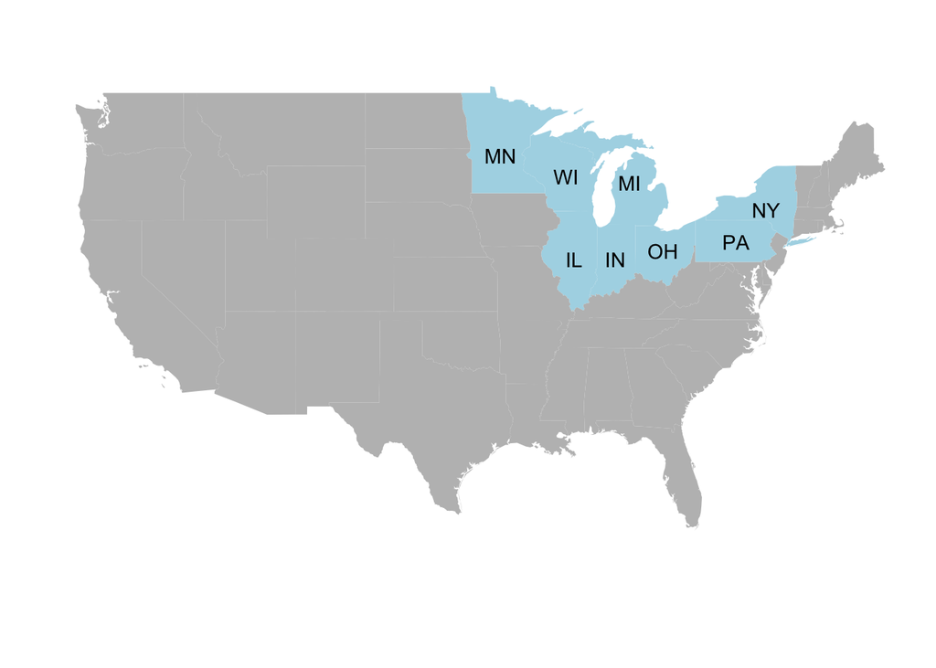

Fig. 1 美国五大湖区的地理位置

## 2. 五大湖区农业区的简介

美国五大湖区的农业非常发达，Fig. 2展示了美国各州的农业总产值， 可以发现上文中提到的几大州，例如明尼苏达州，伊利诺伊州， 印第安纳州和俄亥俄州的年产值都在60亿美元以上。

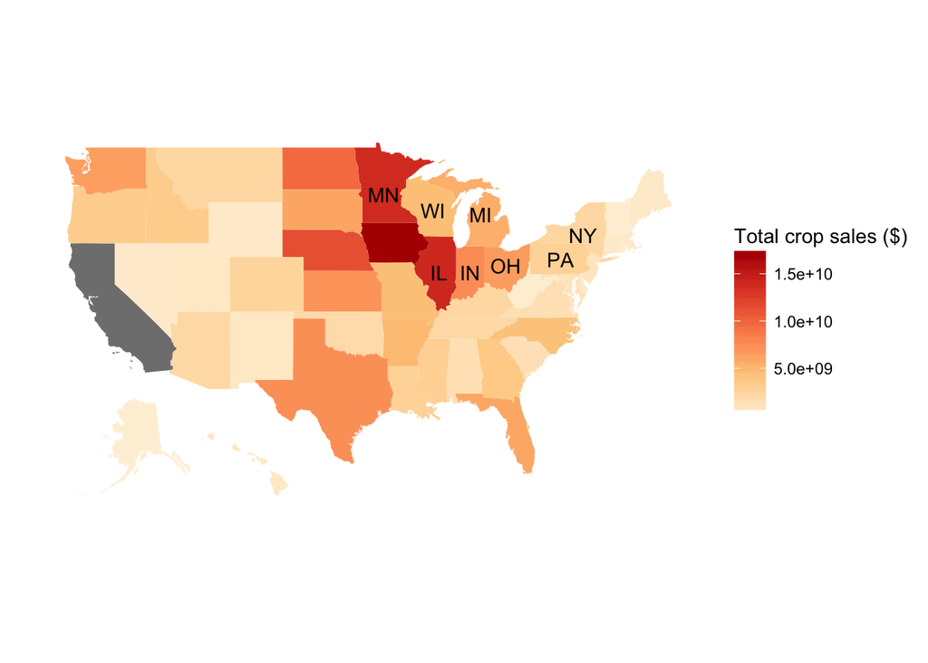

Fig. 2 美国大陆地区各州农业总产值 (Data source: 2012 Census of Agriculture) [注2]

实际上，自从上世纪七十年代以来，当地的农业开发就已经非常成熟，机械化农业、化肥和农药的广泛应用也加速了农业 的发展。但是不同于我国，美国的农业土壤依然保持了较强的肥力和生产力，详情请看本题中知友的答案。

## 3. 农业生产情况下保持土壤肥力的原因

### 3.1 气候原因

一般大家认为黑土地的土壤比较肥沃，例如东北的“北大仓”。 实际上，黑土的“黑色”主要来源于土壤中的有机质。五大湖区的气候与我国东北地区有相似之处， 最主要的相同点就是相对较低的气温与冬季的冰冻期。 Fig. 3 展示了俄亥俄州的克利夫兰市 (Cleveland)的多年月平均气温。当地的平均气温在 10.8 摄氏度左右，每年的11月 份末和3月份初为冰冻期。较低的气温能够减少土壤中有机质的消耗，有利于土壤有机质的积累。更多延展阅读见：

https://www.zhihu.com/question/26702027/answer/49394793

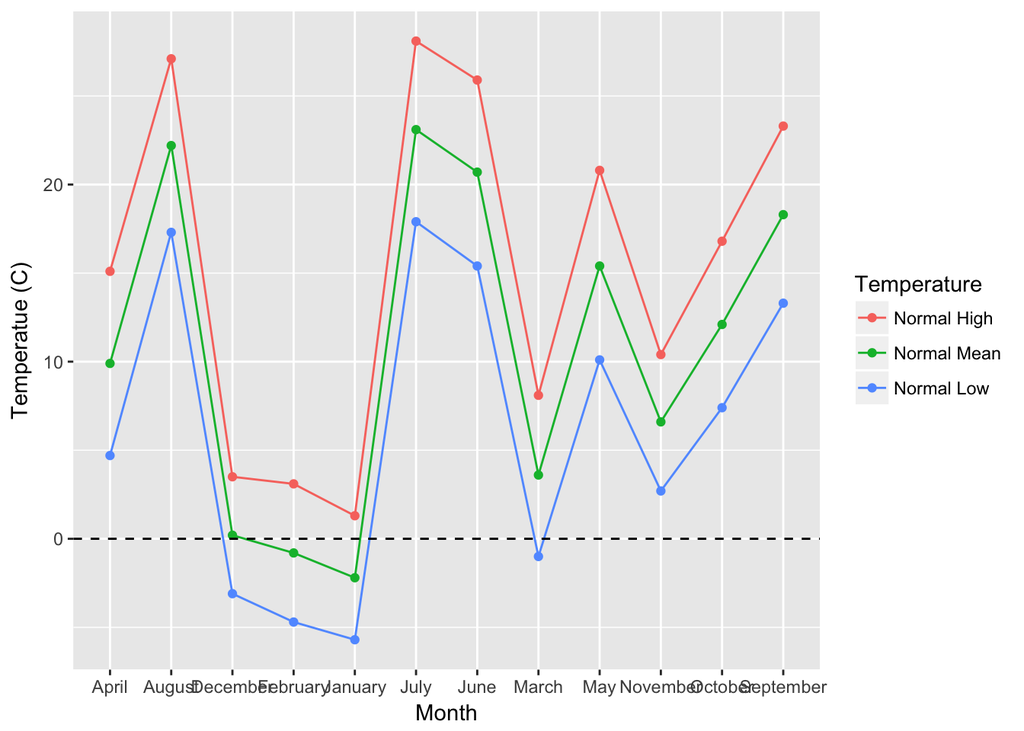

Fig. 3 俄亥俄州某地的多年月平均气温 (Data source: NOAA)

### 3.2 保护性耕作 (Conservative tillage or non tillage)

除了气候原因之外，美国的农业工作者也一直在致力于通过工程和管理途径来保持土壤肥力。自从经历了上世纪的“黑风暴”之后，美国提出了保护性耕作( Conservative tillage or Non tillage)的思想. 尤其是高效除草剂发明之后，保护性耕作带来的杂草滋生问题得到了缓解，保护性耕作得到了大规模的推广。现在美国拓展了保护性耕作的概念，更多的提出了Crop residue management (作物残留物管理)的概念。主要思想是将秸秆等作物残留物留在农田里，增加土壤的有机物供给。Crop resiue managment的主要应用就包括保护性耕作与轮作等方式。据美国自然资源保护局(NRCS)是数据显示，俄亥俄州的Sandusky 流域(大部分为农业用地)应用较高的作物残留物管理措施 的比例从**1982年的5.2%增长到了2012年的64%**，这说明该流域超过一半的耕地都应用了各种类型的作物残留物管理措施[注3]。

延伸阅读： https://zhuanlan.zhihu.com/p/19928530 https://www.zhihu.com/question/25104042/answer/30545715

### 3.3 轮作与休耕

如果长时间种植同一种作物，例如玉米，土壤中的某些特定的营养元素就会消耗过多，不利于保持土壤肥力。美国在上世纪大规模推广了轮作制度，最常见的是“玉米-冬小麦-大豆”轮作。下图就是一个典型的玉米收获之后种植冬小麦的场景，图纸明显能够看到地表还残留玉米的秸秆。在这种轮作中，尤其重要的是种植大豆。大豆作为豆科植物，根系中共生有根瘤菌，能够从大气中固定氮元素，所以种植大豆能够增加土壤的氮素含量，增加土壤肥力。与此同时，大豆收货之后，农民一般都会休耕半年左右，等到来年继续种植玉米，给了土壤一些休养生息的时间。

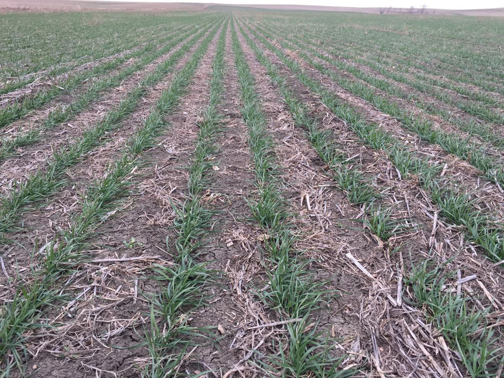

Fig. 4 美国某地小麦长势图[Photo source](http://www.capjournal.com/news/sd-winter-wheat-crop-looking-better-but-not-much-good/article_a2d76b54-c378-11e7-b604-6b4e2aa6f7aa.html)

### 3.4 持续施用化肥

美国五大湖区的农业产出需要从土壤中提取大量的氮磷等营养物，如果没有足够的营养元素输入，土壤中的营养元素就会大量流失。自从上世纪人类发明了化肥，一种可以迅速增加土壤氮磷含量的人工合成物，农业是的生产得到了极大的提升。Fig. 5 中展示了五大湖区各州自从1945到2012年以来的农田的氮磷施用量。自1960年以来，各州的氮磷施用量都在快速增加，到1980年左右达到峰值，施肥量最多的伊利诺伊州在1980s能都达到约10亿kg的氮肥和超过2亿的磷肥。大量的化肥为农业生产提供了足够的营养物质，立下了汗马功劳。

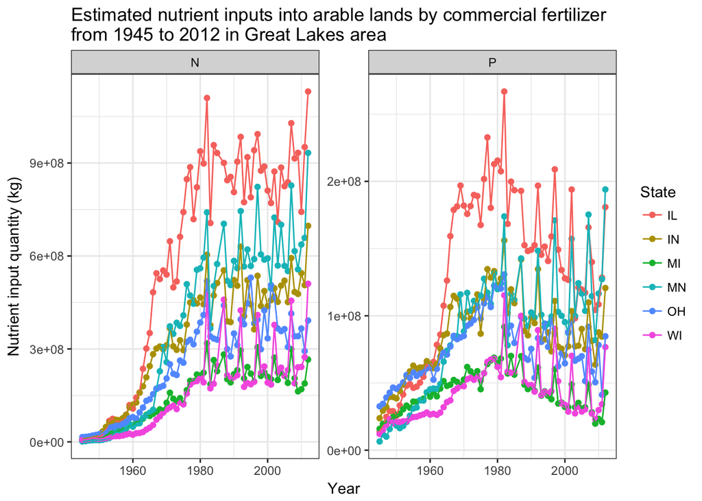

Fig. 5 五大湖区部分州农田化肥使用量(1945 - 2012)

但是，大量的使用化肥也不是没有代价的，最大的危害之一就是受纳水体的富营养化。上世纪70年代以来，美国的墨西哥湾和五大湖区频发富营养化带来的藻类滋生和鱼类大规模窒息死亡现象。最终科学家研究发现农业排水带来的超量氮磷污染物是水体富营养化的主要来源，详细介绍见(https://www.zhihu.com/question/28058420/answer/39459068)。自那时起，美国上下投入大量人力物力来治理水体富营养化，但是成效不尽如人意。目前证明比较有效的途径包括： 减少肥料使用量、提高肥料利用效率 (Nutrient Use Efficiency, NUE)，采用农业最佳管理措施(Best Management Practices, BMPs)等. 由于农业污染的影响因素众多，涉及方面非常广泛，现在相关农业与环境研究者们正在试图从各个角度来探索减少营养物排放的方法与技术。

## 4. 对我国农业生产的启示

在我国的很多地区，土壤退化已经成为了一个触目惊心的问题，包括土壤酸化、土壤荒漠化、“黑土地”消失等原因。借鉴美国的经验和我国的实际情况，窃以为有几点是需要我国农业工作者进行深入研究的：

- 秸秆还田
- 保护性耕作
- 提高化肥利用效率
- 完善田间管理设施和制度

## 5. Take-home points

- 美国五大湖区很多地区土壤肥沃、农业发达、农业产值非常高；
- 在高强度的农业生产活动下，良好的农业土壤管理措施保证了土壤肥力的可持续利用；
- 我国应加强土壤健康管理的意识和措施。

## The end.

注1：严格来讲，这几个州很多地区数据别的流域，例如密西西比河流域，这里不做严格区分。

注2： 为了更好的展示五大湖区的农业数据，加州(California) 数据被移除。

注3：[data source](https://dl.sciencesocieties.org/publications/jeq/supplements/46/123-supplement1.pdf)